# proyecto_contingencias_ii

# Preparación inicial

Inicialmente, se importan las librerías requeridas para el proyecto.

```r
pacman::p_load(dplyr,
               ggplot2,
               readxl,
               tidyr,
               xtable)
```

## Fuerzas de mortalidad

Se obtienen las tablas con los parámetros de las fuerzas de mortalidad para cada edad.

```r
# Se importa la tabla masculina de intensidades graduales a estados de restricción de actividad central
hombres_restr <- read_excel("data/Tablas Proyecto Final.xlsx",
                            sheet = "h_estados_restr")

# Se importa la tabla femenina de intensidades graduales a estados de restricción de actividad central
mujeres_restr <- read_excel("data/Tablas Proyecto Final.xlsx",
                            sheet = "m_estados_restr")

# Se importa la tabla masculina transiciones graduales de recuperación
hombres_recup <- read_excel("data/Tablas Proyecto Final.xlsx",
                            sheet = "h_recuperación")

# Se importa la tabla femenina transiciones graduales de recuperación
mujeres_recup <- read_excel("data/Tablas Proyecto Final.xlsx",
                            sheet = "m_recuperación")

# Se importa la tabla masculina intensidades de transición graduales de mortalidad
hombres_mort <- read_excel("data/Tablas Proyecto Final.xlsx",
                           sheet = "h_mortalidad")

# Se importa la tabla femenina intensidades de transición graduales de mortalidad
mujeres_mort <- read_excel("data/Tablas Proyecto Final.xlsx",
                           sheet = "m_mortalidad")
```

Se procede con las funciones para obtener las fuerzas de mortalidad, inicialmente, con las fuerzas que transicionan de los estados en donde el individuo se encuentra con vida hacia adelante ($\mu_{x}^{ij} \hspace{0.5cm} \forall i, j \in \{1, 2, \dots, 5\} \hspace{0.1cm} \wedge \hspace{0.1cm} i < j$).

```r
# Función para obtener las intensidades de transición graduales a estados de restricción de actividad central
# x: edad
# tabla: hombres_restr o mujeres_restr
# mu: mu_12, mu_13, mu_14, mu_15, mu_23, mu_24, mu_25, mu_34, mu_35 o mu_45
restr_act_central <- function(x, tabla, mu) {
  # Se separan los casos para edades menores a 65
  if (x <= 65) {
    valor_mu <-
      (tabla[[mu]][1] + tabla[[mu]][2] * (tabla[[mu]][3]) ^ x) / (1 + tabla[[mu]][4] * (tabla[[mu]][3]) ^
                                                                    x + tabla[[mu]][5] * (tabla[[mu]][3]) ^ (-x)) + tabla[[mu]][6]
  } else {
    valor_mu <-
      tabla[[mu]][8] * (x - 65) ^ 5 + tabla[[mu]][9] * (x - 65) ^ 4 + tabla[[mu]][10] * (x - 65) ^
      3 + tabla[[mu]][11] * (x - 65) ^ 2 + tabla[[mu]][12] * (x - 65) + tabla[[mu]][13]

  }

  return(valor_mu)

}

(prueba_1h <- restr_act_central(20, hombres_restr, "mu_12"))
```

```
## [1] 0.006321869
```

```r
(prueba_1m <- restr_act_central(21, mujeres_restr, "mu_12"))
```

```
## [1] 0.005269729
```

Seguidamente, la función para obtener las fuerzas de recuperación ($\mu_{x}^{ij} \hspace{0.5cm} \forall i, j \in \{1, 2, \dots, 5\} \hspace{0.1cm} \wedge \hspace{0.1cm} i > j$).

```r
# Función para calcular las intensidades de transición graduales a recuperación
# x: edad
# tabla: hombres_recup o mujeres_recup
# mu: mu_21, mu_32, mu_43 o mu_54
recuperacion <- function(x, tabla, mu) {
  valor_mu <-
    (tabla[[mu]][1] + exp(tabla[[mu]][2] + tabla[[mu]][3] * x)) / (1 + tabla[[mu]][1] + exp(tabla[[mu]][2] + tabla[[mu]][3] * x))

  return(valor_mu)
}

(prueba_2h <- recuperacion(20, hombres_recup, "mu_21"))
```

```
## [1] 0.1716169
```

```r
(prueba_2m <- recuperacion(21, mujeres_recup, "mu_21"))
```

```
## [1] 0.1641523
```

Luego, la función para obtener las fuerzas de transición hacia la muerte ($\mu_{x}^{i6} \hspace{0.5cm} \forall i \in \{1, 2, \dots, 5\}$).

```r
# Función para calcular las intensidades de transición graduales a mortalidad
# x: edad
# tabla: hombres_recup o mujeres_recup
# mu: mu_16, mu_26, mu_36, mu_46 o mu_56
mortalidad <- function(x, tabla, mu) {
  valor_mu <-
    tabla[[mu]][1] + tabla[[mu]][2] * x + exp(tabla[[mu]][3] + tabla[[mu]][4] * x)

  return(valor_mu)

}

(prueba_3h <- mortalidad(20, hombres_mort, "mu_16"))
```

```
## [1] 0.001653346
```

```r
(prueba_3m <- mortalidad(21, mujeres_mort, "mu_16"))
```

```
## [1] 0.0009202219
```

## Probabilidades de transición

Se obtienen las tablas con las probabilidades de transición expuestas en el paper.

```r
# Importar tablas con probabilidades de transición
hombres_prob_transicion <-
  read_excel("data/Tablas Proyecto Final.xlsx",
             sheet = "h_prob_transicion")
mujeres_prob_transicion <-
  read_excel("data/Tablas Proyecto Final.xlsx",
             sheet = "m_prob_transicion")
```

Se modifican los nombres de las columnas correspondientes.

```r
colnames(hombres_prob_transicion)[1:2] <- c("Edad", "Capaz")
colnames(mujeres_prob_transicion)[1:2] <- c("Edad", "Capaz")
```

Se obtienen, por separado, las probabilidades de transición de cada estado. Esto quiere decir que el índice de la lista coincide con el estado correspondiente, por ejemplo, prob_hombres[[2]] coincide con el estado leve (2).

Junto a lo anterior, en el paper se menciona que no todas las filas suman 1, por lo cual, se hará una corrección uniforme a cada edad para que los modelos tengan sentido.

```r
# Se crea una lista para las probabilidades de cada sexo
prob_hombres <- list()
prob_mujeres <- list()

# Se itera para separar las probabilidades por estados
for (i in c(1:6)) {
  prob_hombres[[i]] <-
    as.data.frame(hombres_prob_transicion[(8 * i - 7):(8 * i - 1),])
  prob_mujeres[[i]] <-
    as.data.frame(mujeres_prob_transicion[(8 * i - 7):(8 * i - 1),])

  # Se pone la edad en el nombre de fila de cada DataFrame
  rownames(prob_hombres[[i]]) <- seq(20, 80, 10)
  rownames(prob_mujeres[[i]]) <- seq(20, 80, 10)

  # Se elimina la columna de edad
  prob_hombres[[i]] <- prob_hombres[[i]] %>%
    select(-Edad)
  prob_mujeres[[i]] <- prob_mujeres[[i]] %>%
    select(-Edad)
}

# Obtenemos la suma de las filas en cada matriz
suma_hombres <- sapply(prob_hombres, rowSums)
suma_mujeres <- sapply(prob_mujeres, rowSums)

# Corregimos las filas que no suman 1
for (i in 1:length(prob_hombres)) {
  # Se separan los casos especiales
  if (i != 3 && i != 4) {
    # Corrección uniforme por edad
    correccion_hombres <- ((1 - suma_hombres[, i]) / 6)
    correccion_mujeres <- ((1 - suma_mujeres[, i]) / 6)

    # Se aplica la corrección
    prob_hombres[[i]] <- prob_hombres[[i]] + correccion_hombres
    prob_mujeres[[i]] <- prob_mujeres[[i]] + correccion_mujeres
  } else if(i == 3){
    # Corrección uniforme por edad
    correccion_hombres <- ((1 - suma_hombres[, i]) / 5)
    correccion_mujeres <- ((1 - suma_mujeres[, i]) / 5)

    # Se aplica la corrección
    prob_hombres[[i]] <- cbind(prob_hombres[[i]][1], prob_hombres[[i]][2:6] + correccion_hombres)
    prob_mujeres[[i]] <- cbind(prob_mujeres[[i]][1], prob_mujeres[[i]][2:6] + correccion_mujeres)
  } else{
    # Corrección uniforme por edad
    correccion_hombres <- ((1 - suma_hombres[, i]) / 4)
    correccion_mujeres <- ((1 - suma_mujeres[, i]) / 4)

    # Se aplica la corrección
    prob_hombres[[i]] <- cbind(prob_hombres[[i]][1:2], prob_hombres[[i]][3:6] + correccion_hombres)
    prob_mujeres[[i]] <- cbind(prob_mujeres[[i]][1:2], prob_mujeres[[i]][3:6] + correccion_mujeres)
  }
}

# Se eliminan las variables innecesarias
rm(correccion_hombres, correccion_mujeres, suma_mujeres, suma_hombres)
```

```r
# Recorremos cada estado
for (i in 1:6) {
  # Iniciamos encontrando las pendientes
  pendientesh <-
    (prob_hombres[[i]][2:7,] - prob_hombres[[i]][1:6,]) / 10
  pendientesm <-
    (prob_mujeres[[i]][2:7,] - prob_mujeres[[i]][1:6,]) / 10

  # Listas para guardar las columnas
  lista_colsh <- list()
  lista_colsm <- list()
  lista_auxh <- list()
  lista_auxm <- list()

  # Construimos cada columna
  for (j in 1:6) {
    # Probabilidades de los hombres
    lista_colsh[[1]] <-
      prob_hombres[[i]][1, j] + pendientesh[1, j] * -2:9
    lista_colsh[[2]] <-
      prob_hombres[[i]][2, j] + pendientesh[2, j] * 0:9
    lista_colsh[[3]] <-
      prob_hombres[[i]][3, j] + pendientesh[3, j] * 0:9
    lista_colsh[[4]] <-
      prob_hombres[[i]][4, j] + pendientesh[4, j] * 0:9
    lista_colsh[[5]] <-
      prob_hombres[[i]][5, j] + pendientesh[5, j] * 0:9
    lista_colsh[[6]] <-
      prob_hombres[[i]][6, j] + pendientesh[6, j] * 0:45

    # Probabilidades de las mujeres
    lista_colsm[[1]] <-
      prob_mujeres[[i]][1, j] + pendientesm[1, j] * -2:9
    lista_colsm[[2]] <-
      prob_mujeres[[i]][2, j] + pendientesm[2, j] * 0:9
    lista_colsm[[3]] <-
      prob_mujeres[[i]][3, j] + pendientesm[3, j] * 0:9
    lista_colsm[[4]] <-
      prob_mujeres[[i]][4, j] + pendientesm[4, j] * 0:9
    lista_colsm[[5]] <-
      prob_mujeres[[i]][5, j] + pendientesm[5, j] * 0:9
    lista_colsm[[6]] <-
      prob_mujeres[[i]][6, j] + pendientesm[6, j] * 0:45

    # Obtenemos el dataframe
    lista_auxh[[j]] <- unlist(lista_colsh)
    lista_auxm[[j]] <- unlist(lista_colsm)
  }

  # Se extraen los dataframes en las probabilidades
  prob_hombres[[i]] <- data.frame(lista_auxh, row.names = 18:115)
  prob_mujeres[[i]] <- data.frame(lista_auxm, row.names = 18:115)
  colnames(prob_hombres[[i]]) <-
    c("Capaz", "Leve", "Moderado", "Severo", "Profundo", "Muerto")
  colnames(prob_mujeres[[i]]) <-
    c("Capaz", "Leve", "Moderado", "Severo", "Profundo", "Muerto")
}

# Se eliminan las variables innecesarias
rm(pendientesh,
   pendientesm,
   lista_auxh,
   lista_auxm,
   lista_colsh,
   lista_colsm)
```

Posteriormente, se procede a obtener las probabilidades de transición de varios pasos, esto para el cálculo de las primas. La fórmula correspondiente viene dada por:

$$_{k}p_{x} ^ {0j} = \sum_{i = 0} ^ {5}
{}_{k - 1}p_{x} ^ {0i} \cdot p_{x + k - 1} ^ {ij}, \hspace{0.3cm} k \geq
2 \hspace{0.1cm} \wedge \hspace{0.1cm} j \in \{0, 1, \dots,
5\}$$

```r
# Función para calcular los kpx^{1j}
# edad: edad del individuo (x)
# tabla_prob: prob_hombres o prob_mujeres
kpx <- function(edad, tabla_prob) {
  # Lista para guardar todos los kpx
  lista_kpx <- list()

  # Se obtienen iterativamente los kpx
  for (i in 1:(114 - edad)) {
    # Término p_{x + k + 1} ^ {ij}
    px_ij <-
      do.call(rbind, lapply(tabla_prob, function(df)
        df[(edad - 17 + i),]))

    # Se dividen por iteraciones
    if (i == 1) {
      # Término _{k - 1}p_{x}^{1i}
      px_anterior <-
        matrix(as.numeric(tabla_prob[[1]][(edad - 17),]),
               nrow = 6,
               ncol = 6)

      # Se obtienen los _{2}p_{x}^{1j}
      lista_kpx[[i]] <- colSums(px_ij * px_anterior)

    } else{
      # Se toman las probabilidades calculadas anteriormente
      px_anterior <-
        matrix(as.numeric(lista_kpx[[(i - 1)]]),
               nrow = 6,
               ncol = 6)

      # Se obtienen los _{2}p_{x}^{1j}
      lista_kpx[[i]] <- colSums(px_ij * px_anterior)
    }
  }

  # Se obtiene el DataFrame con los datos correspondientes
  df <- as.data.frame(t(data.frame(lista_kpx)))

  # Se agregan las transiciones de 1 paso
  df <- rbind(tabla_prob[[1]][(edad - 17), ], df)

  # Ajustamos las últimas probabilidades
  df[nrow(df), ] <- 0
  df[nrow(df), ncol(df)] <- 1

  # Se modifican los nombres de las filas
  rownames(df) <- 1:(115 - edad)
  return(df)
}
```

Se realiza un ejemplo de la función anterior.

```r
prueba_kpx <- kpx(18, prob_mujeres)
```

# Cálculo de las primas

Primeramente se crea una función que devuelva el valor de un seguro completo para una vida de edad x. Para esto, se considera la siguiente fórmula:

$$A_x^{05} = v \cdot p_x^{05} +
\sum_{k=1}^{114-x} \left[ v^{k+1} \cdot \sum_{z=0}^{4} _kp_x^{0z} \cdot
p_{x+k}^{z5} \right]$$

```r
# Función para calcular el seguro de vida completo del producto
# x: edad de la persona
# v: vector con los facotres de descuento
# matriz_kpx: matriz con los kpx^{0j}
# tabla_prob: prob_hombres o prob_mujeres
Ax05 <- function(x, v, matriz_kpx, tabla_prob) {
  seguro_completo <- v[1] * matriz_kpx[1, 6]

  for (k in 1:(114 - x)) {
    kpx0z <- matriz_kpx[k, 1:5]

    pxk_z5 <- c(tabla_prob[[1]][x + k - 17, 6],
                tabla_prob[[2]][x + k - 17, 6],
                tabla_prob[[3]][x + k - 17, 6],
                tabla_prob[[4]][x + k - 17, 6],
                tabla_prob[[5]][x + k - 17, 6])

    seguro_completo <- seguro_completo + v[k + 1] * sum(kpx0z * pxk_z5)
  }

  return(seguro_completo)
}
```

Con esto, se procede a determinar las primas brutas anuales por edad para cada sexo.

```r
# Tasa equivalente que se usará en los cálculos
j <- 0.0097

# Montos de los beneficios sin gastos
S <- 3000000
c1 <- 1380000
c2 <- 2069000
c3 <- 10039000
c4 <- 14368000

# Vectores con las primas brutas
primas_brutash <- c()
primas_brutasm <- c()

# Iteramos sobre cada edad para determinar las primas
for (x in 18:64) {
  # Vector con los factores de descuento
  v_j <- (1 + j) ^ (-(1:(115 - x)))

  # Generamos la matriz con los kpx para ambos sexos
  kpx_h <- kpx(x, prob_hombres)
  kpx_m <- kpx(x, prob_mujeres)

  # Se determina la prima para un hombre de edad x

  # Seguro de vida completo
  Ax_05 <- Ax05(x, v_j, kpx_h, prob_hombres)

  # Anualidad de las primas
  ax00 <- 1 + ifelse(x < 64, (sum(v_j[1:(64 - x)] * kpx_h[1:(64 - x), 1])), 0)

  # Anualidad para el estado leve
  ax01 <- sum(v_j * kpx_h[, 2])

  # Anualidad para el estado moderado
  ax02 <- sum(v_j * kpx_h[, 3])

  # Anualidad para el estado severo
  ax03 <- sum(v_j * kpx_h[, 4])

  # Anualidad para el estado profundo
  ax04 <- sum(v_j * kpx_h[, 5])

  # Calculamos la prima con todo lo anterior
  prima <- (S * Ax_05 + c1 * ax01 + c2 * ax02 + c3 * ax03 + c4 * ax04) / (ax00)
  # Guardamos la prima para alguien de edad x en el vector de primas
  primas_brutash <- c(primas_brutash, prima)

  # Analogamente se determina la prima para una mujer de edad x

  # Seguro de vida completo
  Ax_05 <- Ax05(x, v_j, kpx_m, prob_mujeres)

  # Anualidad de las primas
  ax00 <- 1 + ifelse(x < 64, (sum(v_j[1:(64 - x)] * kpx_m[1:(64 - x), 1])), 0)

  # Anualidad para el estado leve
  ax01 <- sum(v_j * kpx_m[, 2])

  # Anualidad para el estado moderado
  ax02 <- sum(v_j * kpx_m[, 3])

  # Anualidad para el estado severo
  ax03 <- sum(v_j * kpx_m[, 4])

  # Anualidad para el estado profundo
  ax04 <- sum(v_j * kpx_m[, 5])

  # Calculamos la prima con todo lo anterior
  prima <- (S * Ax_05 + c1 * ax01 + c2 * ax02 + c3 * ax03 + c4 * ax04) / (ax00)
  # Guardamos la prima para alguien de edad x en el vector de primas
  primas_brutasm <- c(primas_brutasm, prima)
}
```

Ahora se determinarán las primas netas anuales por edad para cada sexo.

```r
# Montos de los beneficios con gastos
S <- S + 100000
c1 <- c1 + 50000
c2 <- c2 + 50000
c3 <- c3 + 50000
c4 <- c4 + 50000

# Vectores con las primas netas
primas_netash <- c()
primas_netasm <- c()

# Iteramos sobre cada edad para determinar las primas
for (x in 18:64) {
  # Vector con los factores de descuento
  v_j <- (1 + j) ^ (-(1:(115 - x)))

  # Generamos la matriz con los kpx para ambos sexos
  kpx_h <- kpx(x, prob_hombres)
  kpx_m <- kpx(x, prob_mujeres)

  # Se determina la prima para un hombre de edad x

  # Seguro de vida completo
  Ax_05 <- Ax05(x, v_j, kpx_h, prob_hombres)

  # Anualidad de las primas
  ax00 <- 1 + ifelse(x < 64, (sum(v_j[1:(64 - x)] * kpx_h[1:(64 - x), 1])), 0)

  # Anualidad para el estado leve
  ax01 <- sum(v_j * kpx_h[, 2])

  # Anualidad para el estado moderado
  ax02 <- sum(v_j * kpx_h[, 3])

  # Anualidad para el estado severo
  ax03 <- sum(v_j * kpx_h[, 4])

  # Anualidad para el estado profundo
  ax04 <- sum(v_j * kpx_h[, 5])

  # Calculamos la prima con todo lo anterior
  prima <- (S * Ax_05 + c1 * ax01 + c2 * ax02 + c3 * ax03 + c4 * ax04) / (0.9 *
                                                                           ax00 - 0.1)
  # Guardamos la prima para alguien de edad x en el vector de primas
  primas_netash <- c(primas_netash, prima)

  # Analogamente se determina la prima para una mujer de edad x

  # Seguro de vida completo
  Ax_05 <- Ax05(x, v_j, kpx_m, prob_mujeres)

  # Anualidad de las primas
  ax00 <- 1 + ifelse(x < 64, (sum(v_j[1:(64 - x)] * kpx_m[1:(64 - x), 1])), 0)

  # Anualidad para el estado leve
  ax01 <- sum(v_j * kpx_m[, 2])

  # Anualidad para el estado moderado
  ax02 <- sum(v_j * kpx_m[, 3])

  # Anualidad para el estado severo
  ax03 <- sum(v_j * kpx_m[, 4])

  # Anualidad para el estado profundo
  ax04 <- sum(v_j * kpx_m[, 5])

  # Calculamos la prima con todo lo anterior
  prima <- (S * Ax_05 + c1 * ax01 + c2 * ax02 + c3 * ax03 + c4 * ax04) / (0.9 *
                                                                           ax00 - 0.1)
  # Guardamos la prima para alguien de edad x en el vector de primas
  primas_netasm <- c(primas_netasm, prima)
}
```

Seguidamente generamos las tablas en formato latex de las primas brutas y netas.

```r
df_primas_netas <- data.frame(primas_netash, primas_netasm)
df_primas_brutas <- data.frame(primas_brutash, primas_brutasm)

colnames(df_primas_netas) <- c("Hombre", "Mujer")
colnames(df_primas_brutas) <- c("Hombre", "Mujer")

rownames(df_primas_netas) <- 18:64
rownames(df_primas_brutas) <- 18:64

tabla_primas_netas <- xtable(df_primas_netas)
tabla_primas_brutas <- xtable(df_primas_brutas)

print(tabla_primas_netas, type = "latex")
```

```
## % latex table generated in R 4.3.1 by xtable 1.8-4 package
## % Mon Nov 18 08:01:48 2024
## \begin{table}[ht]
## \centering
## \begin{tabular}{rrr}
##   \hline
##  & Hombre & Mujer \\
##   \hline
## 18 & 1451505.25 & 1956377.83 \\
##   19 & 1480994.95 & 1998467.43 \\
##   20 & 1511704.02 & 2042429.44 \\
##   21 & 1543727.17 & 2088403.41 \\
##   22 & 1577168.93 & 2136542.94 \\
##   23 & 1612144.85 & 2187017.43 \\
##   24 & 1648783.09 & 2240014.21 \\
```

[output cut: 43 more lines]

```r
print(tabla_primas_brutas, type = "latex")
```

```
## % latex table generated in R 4.3.1 by xtable 1.8-4 package
## % Mon Nov 18 08:01:48 2024
## \begin{table}[ht]
## \centering
## \begin{tabular}{rrr}
##   \hline
##  & Hombre & Mujer \\
##   \hline
## 18 & 1287442.65 & 1739826.86 \\
##   19 & 1313517.10 & 1777167.67 \\
##   20 & 1340666.04 & 1816165.09 \\
##   21 & 1368972.79 & 1856942.30 \\
##   22 & 1398529.21 & 1899634.81 \\
##   23 & 1429436.88 & 1944392.06 \\
##   24 & 1461808.39 & 1991379.22 \\
```

[output cut: 43 more lines]

Por último, realizamos los gráficos para visualizar ambos tipos de primas.

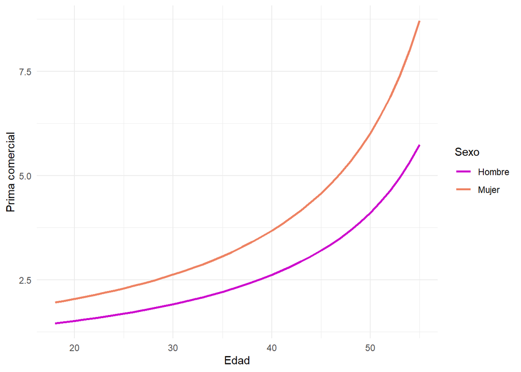

```r
# Gráficos primas netas
ggplot(df_primas_netas[1:38, ], aes(x = 18:55)) +
  geom_line(aes(y = Hombre / 1000000, color = "H"), linewidth = 1) +
  geom_line(aes(y = Mujer / 1000000, color = "M"), linewidth = 1) +
  labs(x = "Edad", y = "Prima comercial", color = "Leyenda") +
  scale_color_manual(
    name = "Sexo",
    values = c("H" = "magenta3", "M" = "salmon2"),
    labels = c("H" = "Hombre", "M" = "Mujer")
  ) +
  theme_minimal()
```

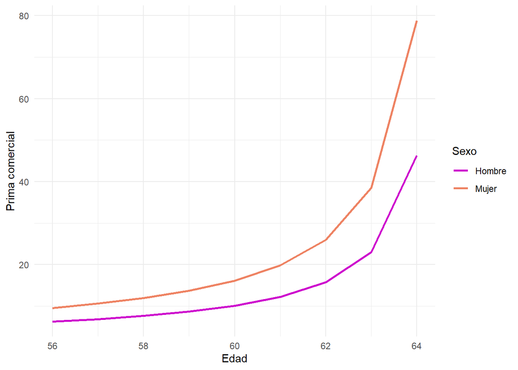

```r
ggplot(df_primas_netas[39:47, ], aes(x = 56:64)) +
  geom_line(aes(y = Hombre / 1000000, color = "H"), linewidth = 1) +
  geom_line(aes(y = Mujer / 1000000, color = "M"), linewidth = 1) +
  labs(x = "Edad", y = "Prima comercial", color = "Leyenda") +
  scale_color_manual(
    name = "Sexo",
    values = c("H" = "magenta3", "M" = "salmon2"),
    labels = c("H" = "Hombre", "M" = "Mujer")
  ) +
  theme_minimal()
```

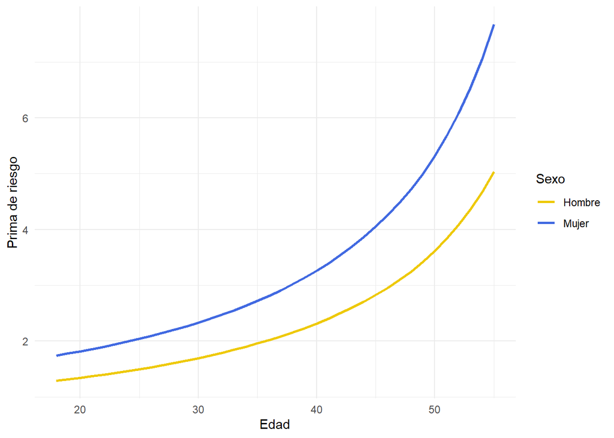

```r
# Gráficos primas brutas
ggplot(df_primas_brutas[1:38, ], aes(x = 18:55)) +
  geom_line(aes(y = Hombre / 1000000, color = "H"), linewidth = 1) +
  geom_line(aes(y = Mujer / 1000000, color = "M"), linewidth = 1) +
  labs(x = "Edad", y = "Prima de riesgo", color = "Leyenda") +
  scale_color_manual(
    name = "Sexo",
    values = c("H" = "gold2", "M" = "royalblue"),
    labels = c("H" = "Hombre", "M" = "Mujer")
  ) +
  theme_minimal()
```

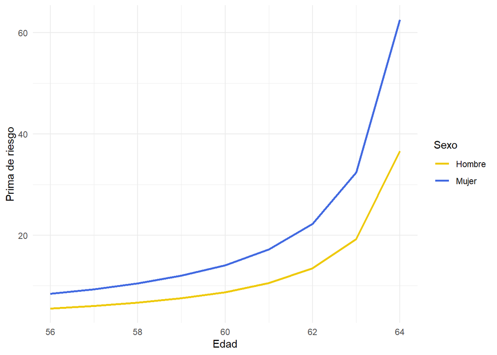

```r
ggplot(df_primas_brutas[39:47, ], aes(x = 56:64)) +
  geom_line(aes(y = Hombre / 1000000, color = "H"), linewidth = 1) +
  geom_line(aes(y = Mujer / 1000000, color = "M"), linewidth = 1) +
  labs(x = "Edad", y = "Prima de riesgo", color = "Leyenda") +
  scale_color_manual(
    name = "Sexo",
    values = c("H" = "gold2", "M" = "royalblue"),
    labels = c("H" = "Hombre", "M" = "Mujer")
  ) +
  theme_minimal()
```

# Rentabilidad del producto

## Cartera de seguros

Se realizó un documento de *MS Excel* con una variedad de personas, estas representan los distintos sexos y edades que se encuentran en la cartera de seguros de la hipotética aseguradora. La justificación de las cantidades de personas, distribuciones de sexo y demás, se encuentra detallado en el documento escrito, como referencia, se realizan algunos graficos descriptivos para la visualización de los datos.

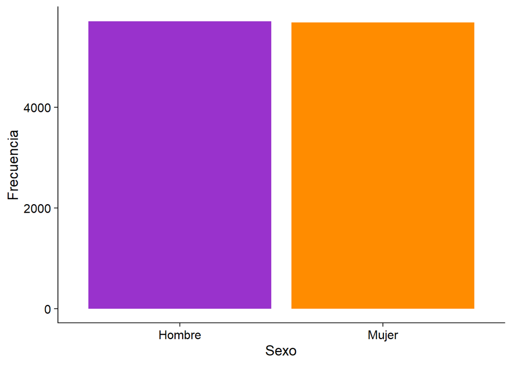

```r
# Se descarga la cartera
cartera_seguros <- read_excel("data/Cartera de seguros.xlsx")

# Se modifican los nombres de los sexos
cartera_seguros <- cartera_seguros %>%
  mutate(Sexo = recode(Sexo, "F" = "Mujer", "M" = "Hombre"))

# Cantidad de personas en la cartera dividida por sexo
cartera_seguros %>%
  ggplot(aes(x = Sexo, fill = Sexo)) +
  geom_bar() +
  labs(x = "Sexo", y = "Frecuencia") +
  cowplot::theme_cowplot() +
  theme(legend.position = "none") +
  scale_fill_manual(values = c("Hombre" = "darkorchid", "Mujer" = "darkorange"))
```

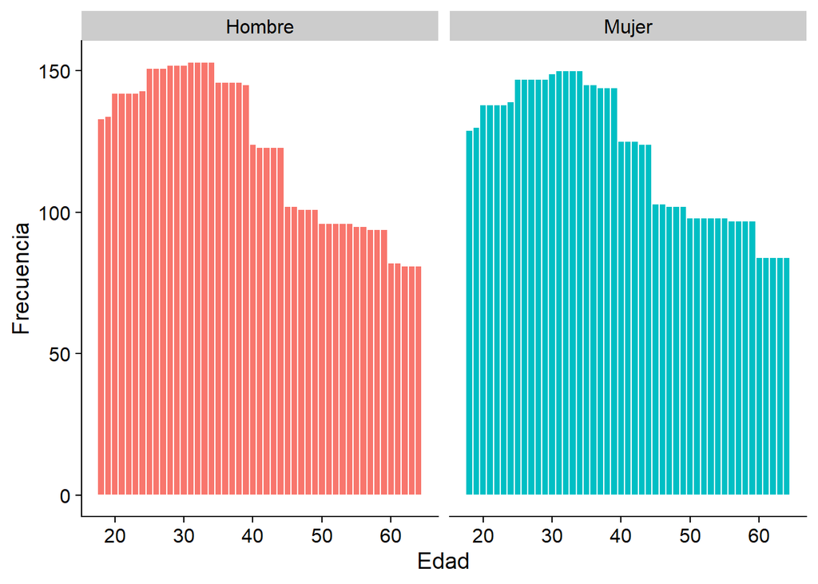

```r
# Cantidad de personas en la cartera por edad dividida por sexo
cartera_seguros %>%
  ggplot(aes(x = Edades, fill = Sexo)) +
  geom_histogram(color = "white", binwidth = 1) +
  facet_wrap( ~ Sexo) +
  labs(x = "Edad", y = "Frecuencia") +
  cowplot::theme_cowplot() +
  theme(legend.position = "none")
```

## Modelos estocásticos

En esta sección se implementarán dos modelos estocásticos. El primero simula la cantidad de personas en los diferentes estados al final de cada año a partir del 2024. El segundo obtendrá los montos esperados de ingresos y egresos para cada uno de los estados. Ambos modelos se realizarán para cada sexo. Para llevar a cabo lo anterior, se desarrollará una función que devuelva una lista que tendrá otras tres listas: una con la proyección de personas en cada estado para cada año y otras dos con la proyección de gastos e ingresos para cada uno de los estados.

```r
# Ingresos determinísticos de hombres
ingresos_h <- data.frame(
  "0" = c(primas_netash, rep(0, 51)),
  "1" = rep(0, 98),
  "2" = rep(0, 98),
  "3" = rep(0, 98),
  "4" = rep(0, 98),
  row.names = 18:115
)

# Ingresos determinísticos de mujeres
ingresos_m <- data.frame(
  "0" = c(primas_netasm, rep(0, 51)),
  "1" = rep(0, 98),
  "2" = rep(0, 98),
  "3" = rep(0, 98),
  "4" = rep(0, 98),
  row.names = 18:115
)
```

Seguidamente se va a generar un vector para cada sexo donde cada uno incluya la cantidad de personas por edad, usando lo realizado en la sección de la cartera de seguros.

```r
poblacion_cartera <- as.data.frame(cartera_seguros)

poblacion_cartera$Edades <- as.numeric(poblacion_cartera$Edades)

hombres_cartera <- table(poblacion_cartera$Edades[poblacion_cartera$Sexo == "Hombre"])
mujeres_cartera <- table(poblacion_cartera$Edades[poblacion_cartera$Sexo == "Mujer"])

# Se ordenan los vectores por edad
edades <- sort(unique(poblacion_cartera$Edades))

hombres_cartera <- as.numeric(hombres_cartera[as.character(edades)])
mujeres_cartera <- as.numeric(mujeres_cartera[as.character(edades)])
```

Con los datos ya construidos, obtenemos la función para el modelo estocástico.

```r
# Función que ejecuta el primer modelo estocástico requerido
# simulaciones: cantidad de simulaciones del modelo estocástico
# tabla_prob: prob_hombres o prob_mujeres
# num_personas: hombres_cartera o mujeres_cartera
# ingresos:
modelo_estoc <- function(simulaciones,
                         tabla_prob,
                         num_personas,
                         ingresos) {
  # Listas con las matrices de cada simulación
  lista_personas <- list()
  lista_gastos <- list()
  lista_ingresos <- list()
  lista_auxi <- list()
  lista_auxg <- list()

  # Matriz de personas
  matriz_personas <- matrix(0, nrow = 97, ncol = 98)

  # Primer columna
  matriz_personas[, 1] <- c(num_personas, rep(0, 50))

  # Valores presentes
  vp <- (1 / (1 + j)) ^ (0:97)

  # LLenamos la matriz
  for (i in 2:47) {
    matriz_personas[, i] <-
      c(rep(0, (i - 1)), num_personas, rep(0, 51 - i))
  }

  # Iteramos la cantidad de simulaciones especificada
  for (simulacion in 1:simulaciones) {

    # Matriz para el escenario de la simulación
    escenario <- matrix(NA, nrow = 97, ncol = 98)

    # Vector con las edades
    edades <- 1:47

    # Las personas de edad 18 a 64 empiezan en el estado 0
    escenario[edades, 1] <- 0

    # Generamos una matriz aleatoria para cada edad
    matrices_aleatorias <- lapply(edades, function(x)
      matrix(runif(98 * 6), nrow = 98, ncol = 6))

    # Lista con los intervalos de transición iniciales
    intervalos_list <- lapply(edades, function(x) {
      unname(cumsum(c(0, tabla_prob[[1]][edades[x],])))
    })

    # Iteramos sobre cada edad
    for (i in edades) {
      # Guardamos la matriz aleatoria y los intervalos correspondientes
      matriz_aleatoria <- matrices_aleatorias[[i]]
      intervalos <- intervalos_list[[i]]

      # Determinamos el nuevo estado para el segundo año (2025)
      estado <-
        which(intervalos[-length(intervalos)] < matriz_aleatoria[i, 1] &
                matriz_aleatoria[i, 1] <= intervalos[-1]) - 1

      # Iteramos sobre los años
      for (k in 1:(97 - i)) {
        # Guardamos el estado de la persona para el año corrrespondiente
        escenario[i + k, 1 + k] <- estado

        # Si el estado es 5 la persona sale del modelo, sino, se determina el nuevo
        # estado al que transiciona
        if (estado < 5) {
          # Vector con los intervalos de transición
          intervalos <-
            unname(cumsum(c(tabla_prob[[estado + 1]][i + k,])))

          # Si el estado es 0 o 1, hay que agregarle un 0 a los intervalos
          if (estado < 2) {
            intervalos <- c(0, intervalos)
          }

          # Se determina el "nuevo estado"
          estado_nuevo <-
            which(intervalos[-length(intervalos)] < matriz_aleatoria[i + k, estado + 1] &
                    matriz_aleatoria[i + k, estado + 1] <= intervalos[-1]) - 1

          # Actualizamos el estado dependiendo del valor del "nuevo estado"
          estado <-
            ifelse(estado_nuevo < estado, estado - 1, estado_nuevo)
        } else{
          # Para no ir acumulando los fallecidos, establecemos el estado en 6 si la
          # persona falleció el año anterior
          estado <- 6

        } # fin if-else
      } # fin for k
    } # fin for i

    # Matriz con la cantidad de personas por año para cada estado
    personas_estados <- matrix(0, nrow = 6, ncol = 98)

    # Llenamos la matriz
    for (i in 0:5) {
      personas_estados[(i + 1),] <- apply(escenario, 2, function(col) {
        col <- col[!is.na(col)]
        sum(num_personas[1:length(col)][col == i])
      })

    }

    # Guardamos la matriz en la lista como un DataFrame
    lista_personas[[simulacion]] <-
      data.frame(personas_estados, row.names = 0:5)

    # Para el otro modelo estocástico, iniciamos obteniendo los gastos según el escenario
    gastos_estoc <-
      ifelse(escenario == 0, 0, ifelse(
        escenario == 1,
        1430000,
        ifelse(
          escenario == 2,
          2119000,
          ifelse(
            escenario == 3,
            10089000,
            ifelse(escenario == 4, 14418000, ifelse(escenario == 5, 3100000, 0))
          )
        )
      ))

    # Ingresos según escenario
    ingresos_estoc <- ifelse(escenario == 0, ingresos[, 1], 0)

    # No se pagan primas después de los 64
    ingresos_estoc[48:nrow(ingresos_estoc), ] <- 0

    # Personas por escenario
    gastos_estoc <- gastos_estoc * matriz_personas
    ingresos_estoc <- ingresos_estoc * matriz_personas

    lista_gastos[[simulacion]] <- gastos_estoc
    lista_ingresos[[simulacion]] <- escenario


    # Iteramos por cada estado para obtener los ingresos/gastos por estado
    for (i in 0:5) {
      # Obtenemos las coincidencias de estados
      coincidencias <- escenario == i

      # Dejamos los valores que coinciden con el estado
      gastos_estado <- gastos_estoc * coincidencias
      ingresos_estado <- ingresos_estoc * coincidencias

      # Sumamos los gastos/ingresos, por separado, en cada uno de los años
      gastos_sum <- colSums(gastos_estado, na.rm = TRUE)
      ingresos_sum <- colSums(ingresos_estado, na.rm = TRUE)

      # Se obtiene el valor presente cada año, para luego sumarse
      lista_auxg[[(i + 1)]] <- sum(gastos_sum * vp)
      lista_auxi[[(i + 1)]] <- sum(ingresos_sum * vp)
    }

    lista_gastos[[simulacion]] <- unname(unlist(lista_auxg))
    lista_ingresos[[simulacion]] <- unname(unlist(lista_auxi)
    )

  } # fin for simulaciones

  return(list(lista_personas, lista_gastos, lista_ingresos))

}
```

Ahora se procederá a determinar la esperanza de las matrices asociadas a las 10 000 simulaciones.

```r
# Definimos la semilla para reproducibilidad
set.seed(2024)

# Cantidad de simulaciones
n_sim <- 10000

# Determinamos las matrices asociadas a las simulaciones determinadas, tanto para hombres y mujeres
simulaciones_h <- modelo_estoc(n_sim, prob_hombres, hombres_cartera, ingresos_h)
simulaciones_m <- modelo_estoc(n_sim, prob_mujeres, mujeres_cartera, ingresos_m)

# Matrices con las esperanzas por estado y para cada año, para cada sexo
esperanzas_personas_h <- Reduce("+", simulaciones_h[[1]]) / n_sim
esperanzas_personas_m <- Reduce("+", simulaciones_m[[1]]) / n_sim

# Esperanzas por estado de gastos
esperanzas_gastos_h <- Reduce("+", simulaciones_h[[2]]) / n_sim
esperanzas_gastos_m <- Reduce("+", simulaciones_m[[2]]) / n_sim

# Esperanzas por estado de ingresos
esperanzas_ingresos_h <- Reduce("+", simulaciones_h[[3]]) / n_sim
esperanzas_ingresos_m <- Reduce("+", simulaciones_m[[3]]) / n_sim
```

## Análisis de resultados

Finalmente, se realizan unos gráficos descriptivos de los modelos estocásticos correspondientes.

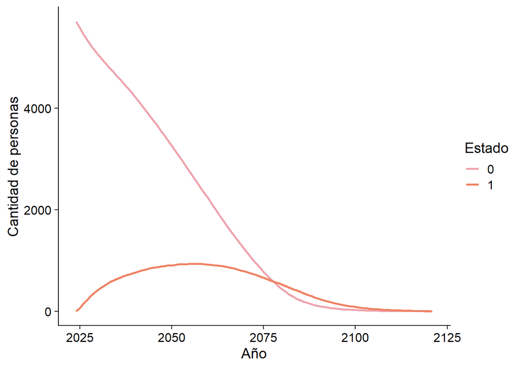

```r
# Se transpone el dataframe de personas hombres
df_personas <- as.data.frame(t(esperanzas_personas_h))

# Se agregan los años al dataframe
df_personas$anno <- 2024:2121

# Se cambian los nombres de las columnas
colnames(df_personas) <-
  c("est_0", "est_1", "est_2", "est_3", "est_4", "est_5", "annos")

# Gráfico de personas, estados 0 y 1
ggplot(df_personas, aes(x = annos)) +
  geom_line(aes(y = est_0, color = "0"), linewidth = 1) +
  geom_line(aes(y = est_1, color = "1"), linewidth = 1) +
  labs(x = "Año", y = "Cantidad de personas") +
  scale_colour_manual(name = "Estado",
                      values = c("0" = "lightpink2",
                                 "1" = "salmon2")) +
  cowplot::theme_cowplot()
```

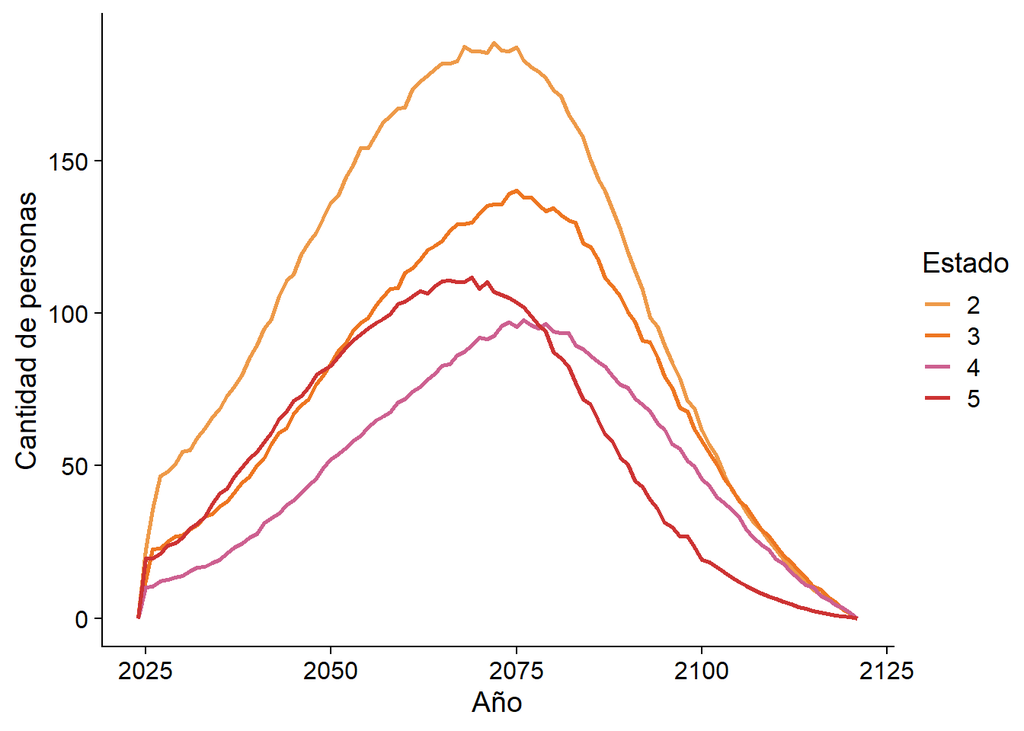

```r
# Gráfico de personas, estados del 2 al 5
ggplot(df_personas, aes(x = annos)) +
  geom_line(aes(y = est_2, color = "2"), linewidth = 1) +
  geom_line(aes(y = est_3, color = "3"), linewidth = 1) +
  geom_line(aes(y = est_4, color = "4"), linewidth = 1) +
  geom_line(aes(y = est_5, color = "5"), linewidth = 1) +
  labs(x = "Año", y = "Cantidad de personas") +
  scale_colour_manual(
    name = "Estado",
    values = c(
      "2" = "tan2",
      "3" = "chocolate2",
      "4" = "hotpink3",
      "5" = "brown3"
    )
  ) +
  cowplot::theme_cowplot()
```

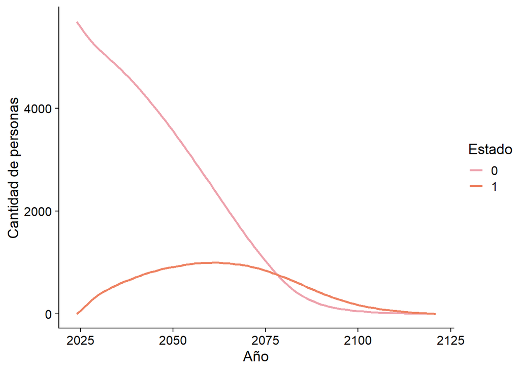

```r
# Se transpone el dataframe de personas mujeres
df_personas <- as.data.frame(t(esperanzas_personas_m))

# Se agregan los años al dataframe
df_personas$anno <- 2024:2121

# Se cambian los nombres de las columnas
colnames(df_personas) <-
  c("est_0", "est_1", "est_2", "est_3", "est_4", "est_5", "annos")

# Gráfico de personas, estados 0 y 1
ggplot(df_personas, aes(x = annos)) +
  geom_line(aes(y = est_0, color = "0"), linewidth = 1) +
  geom_line(aes(y = est_1, color = "1"), linewidth = 1) +
  labs(x = "Año", y = "Cantidad de personas") +
  scale_colour_manual(name = "Estado",
                      values = c("0" = "lightpink2",
                                 "1" = "salmon2")) +
  cowplot::theme_cowplot()
```

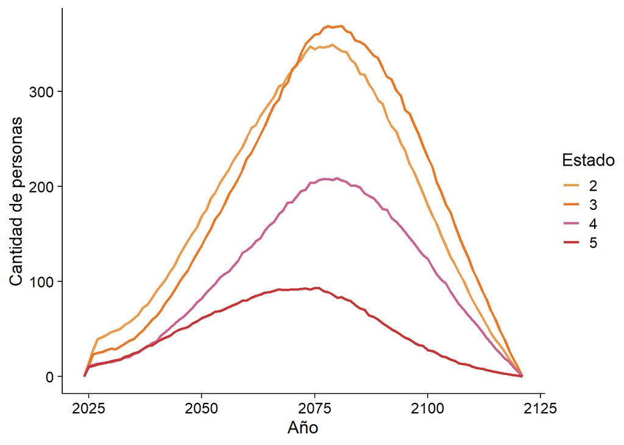

```r
# Gráfico de personas, estados del 2 al 5
ggplot(df_personas, aes(x = annos)) +
  geom_line(aes(y = est_2, color = "2"), linewidth = 1) +
  geom_line(aes(y = est_3, color = "3"), linewidth = 1) +
  geom_line(aes(y = est_4, color = "4"), linewidth = 1) +
  geom_line(aes(y = est_5, color = "5"), linewidth = 1) +
  labs(x = "Año", y = "Cantidad de personas") +
  scale_colour_manual(
    name = "Estado",
    values = c(
      "2" = "tan2",
      "3" = "chocolate2",
      "4" = "hotpink3",
      "5" = "brown3"
    )
  ) +
  cowplot::theme_cowplot()
```

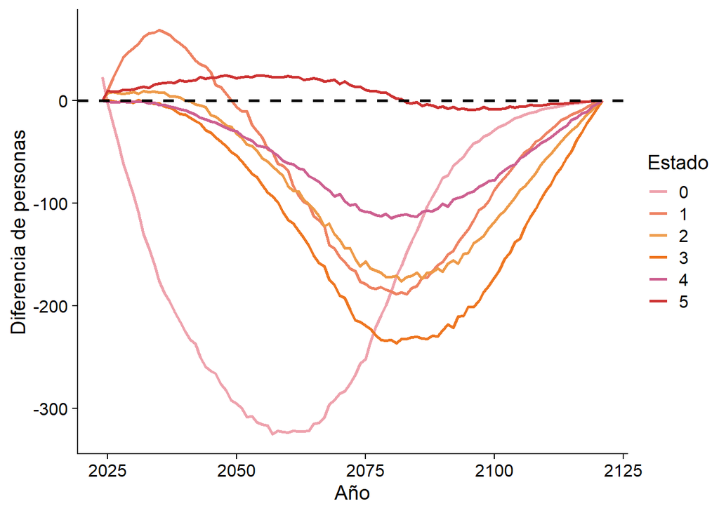

```r
# Dataframe de comparación de personas por sexo
df_comparacion <- esperanzas_personas_h - esperanzas_personas_m

# Se transpone el dataframe de personas mujeres
df_comparacion <- as.data.frame(t(df_comparacion))

# Se agregan los años al dataframe
df_comparacion$anno <- 2024:2121

# Se cambian los nombres de las columnas
colnames(df_comparacion) <-
  c("est_0", "est_1", "est_2", "est_3", "est_4", "est_5", "annos")

# Gráfico de personas, estados del 0 al 1
ggplot(df_comparacion, aes(x = annos)) +
  geom_line(aes(y = est_0, color = "0"), linewidth = 1) +
  geom_line(aes(y = est_1, color = "1"), linewidth = 1) +
  geom_line(aes(y = est_2, color = "2"), linewidth = 1) +
  geom_line(aes(y = est_3, color = "3"), linewidth = 1) +
  geom_line(aes(y = est_4, color = "4"), linewidth = 1) +
  geom_line(aes(y = est_5, color = "5"), linewidth = 1) +
  geom_hline(
    yintercept = 0,
    linetype = "dashed",
    color = "black",
    linewidth = 1
  ) +
  labs(x = "Año", y = "Diferencia de personas") +
  scale_colour_manual(
    name = "Estado",
    values = c(
      "0" = "lightpink2",
      "1" = "salmon2",
      "2" = "tan2",
      "3" = "chocolate2",
      "4" = "hotpink3",
      "5" = "brown3"
    )
  ) +
  cowplot::theme_cowplot()
```

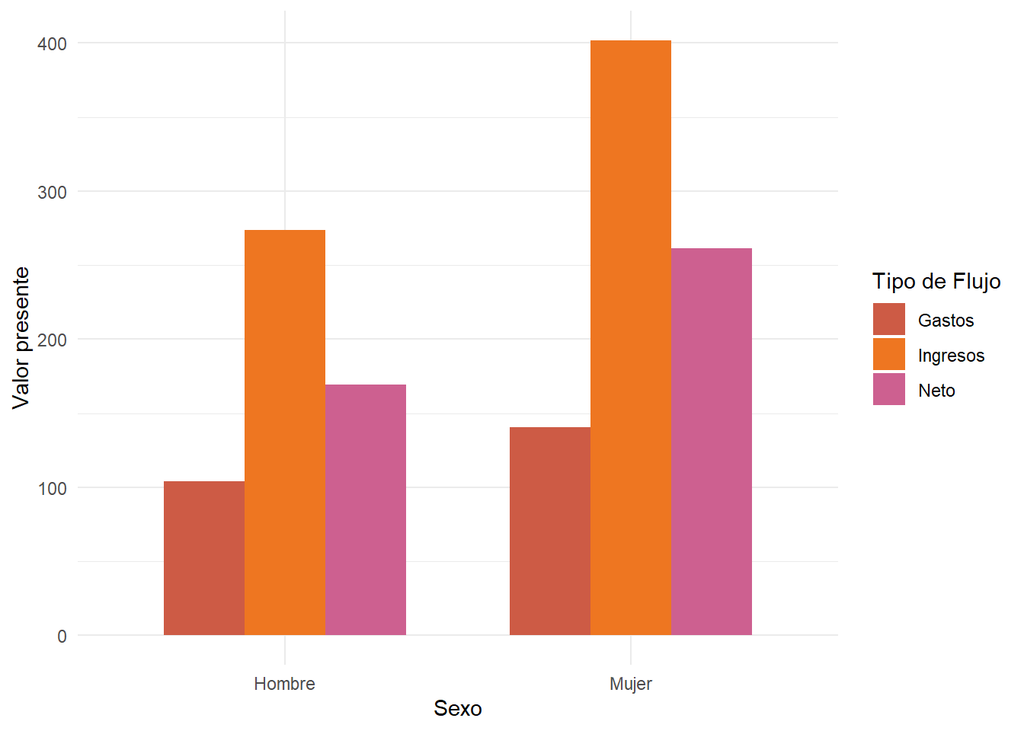

```r
# Dataframe para los gastos e ingresos
df_flujos <-
  data.frame(
    sexo = c("Hombre", "Mujer"),
    gastos = c(sum(esperanzas_gastos_h), sum(esperanzas_gastos_m)),
    ingresos = c(sum(esperanzas_ingresos_h), sum(esperanzas_ingresos_m))
  )

# Dataframe para el flujo neto
df_flujos <- df_flujos %>%
  mutate(neto = ingresos - gastos)

# Se ponen los flujos en formato largo
df_flujos <- df_flujos %>%
  pivot_longer(
    cols = c(gastos, ingresos, neto),
    names_to = "Categoria",
    values_to = "valor"
  )

# Gráfico de gastos, ingresos y flujo neto
ggplot(df_flujos, aes(
  x = sexo,
  y = (valor / 1000000000),
  fill = Categoria
)) +
  geom_bar(stat = "identity",
           position = "dodge",
           width = 0.7) +
  labs(x = "Sexo", y = "Valor presente") +
  scale_fill_manual(
    name = "Tipo de Flujo",
    values = c(
      "gastos" = "coral3",
      "ingresos" = "chocolate2",
      "neto" = "hotpink3"
    ),
    labels = c("gastos" = "Gastos", "ingresos" = "Ingresos", "neto" = "Neto")
  ) +
  theme_minimal()
```

```r
tabla_flujos <- xtable(df_flujos)
print(tabla_flujos, type = "latex")
```

```
## % latex table generated in R 4.3.1 by xtable 1.8-4 package
## % Mon Nov 18 08:51:48 2024
## \begin{table}[ht]
## \centering
## \begin{tabular}{rllr}
##   \hline
##  & sexo & Categoria & valor \\
##   \hline
## 1 & Hombre & gastos & 104161531518.44 \\
##   2 & Hombre & ingresos & 273536361352.13 \\
##   3 & Hombre & neto & 169374829833.69 \\
##   4 & Mujer & gastos & 140418027466.01 \\
##   5 & Mujer & ingresos & 401573730913.88 \\
##   6 & Mujer & neto & 261155703447.86 \\
##    \hline
## \end{tabular}
## \end{table}
```

# Análisis de sensibilidad

A continuación se realizarán dos análisis de sensibilidad que ayudarán a construir un análisis más completo del llevado a cabo.

## Tamaño de la cartera

Debido a que las primas del producto son muy elevadas para edades avanzadas, para este análisis de sensibilidad, y por realismo, se asumirá que solo tomarán la póliza las personas con edad de 18 a 50 años de la cartera construida.

```r
# Definimos la semilla para reproducibilidad
set.seed(2024)

# Cantidad de simulaciones
n_sim <- 10000

# Guardamos la cantidad de personas de la cartera con edad de 18 a 50
# Por lo que la cantidad de personas de edad 51 a 64 es de 0
hombres_sen <- c(hombres_cartera[1:33], rep(0, length(hombres_cartera) - 33))
mujeres_sen <- c(mujeres_cartera[1:33], rep(0, length(mujeres_cartera) - 33))

# Determinamos las matrices asociadas a las simulaciones determinadas, tanto para hombres y mujeres
sim_hsen <- modelo_estoc(n_sim, prob_hombres, hombres_sen, ingresos_h)
sim_msen <- modelo_estoc(n_sim, prob_mujeres, mujeres_sen, ingresos_m)

# Matrices con las esperanzas por estado y para cada año, para cada sexo
esp_per_hsen <- Reduce("+", sim_hsen[[1]]) / n_sim
esp_per_msen <- Reduce("+", sim_msen[[1]]) / n_sim

# Esperanzas por estado de gastos
esp_gast_hsen <- Reduce("+", sim_hsen[[2]]) / n_sim
esp_gast_msen <- Reduce("+", sim_msen[[2]]) / n_sim

# Esperanzas por estado de ingresos
esp_ing_hsen <- Reduce("+", sim_hsen[[3]]) / n_sim
esp_ing_msen <- Reduce("+", sim_msen[[3]]) / n_sim
```

Graficamos los resultados de este análisis de sensibilidad.

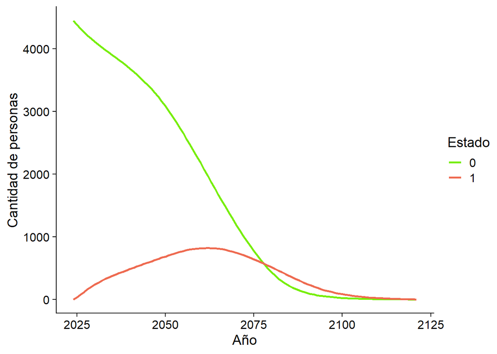

```r
# Se transpone el dataframe de personas hombres
df_personas <- as.data.frame(t(esp_per_hsen))

# Se agregan los años al dataframe
df_personas$anno <- 2024:2121

# Se cambian los nombres de las columnas
colnames(df_personas) <-
  c("est_0", "est_1", "est_2", "est_3", "est_4", "est_5", "annos")

# Gráfico de personas, estados 0 y 1
ggplot(df_personas, aes(x = annos)) +
  geom_line(aes(y = est_0, color = "0"), linewidth = 1) +
  geom_line(aes(y = est_1, color = "1"), linewidth = 1) +
  labs(x = "Año", y = "Cantidad de personas") +
  scale_colour_manual(name = "Estado",
                      values = c("0" = "chartreuse2",
                                 "1" = "coral2")) +
  cowplot::theme_cowplot()
```

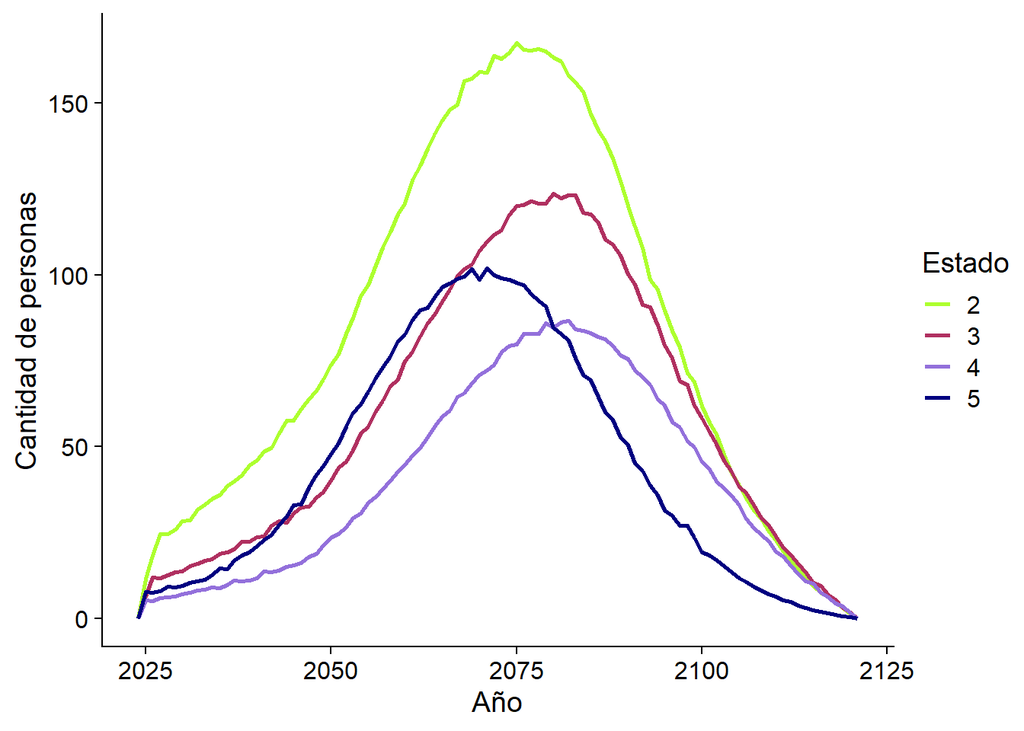

```r
# Gráfico de personas, estados del 2 al 5
ggplot(df_personas, aes(x = annos)) +
  geom_line(aes(y = est_2, color = "2"), linewidth = 1) +
  geom_line(aes(y = est_3, color = "3"), linewidth = 1) +
  geom_line(aes(y = est_4, color = "4"), linewidth = 1) +
  geom_line(aes(y = est_5, color = "5"), linewidth = 1) +
  labs(x = "Año", y = "Cantidad de personas") +
  scale_colour_manual(
    name = "Estado",
    values = c(
      "2" = "greenyellow",
      "3" = "maroon",
      "4" = "mediumpurple",
      "5" = "navy"
    )
  ) +
  cowplot::theme_cowplot()
```

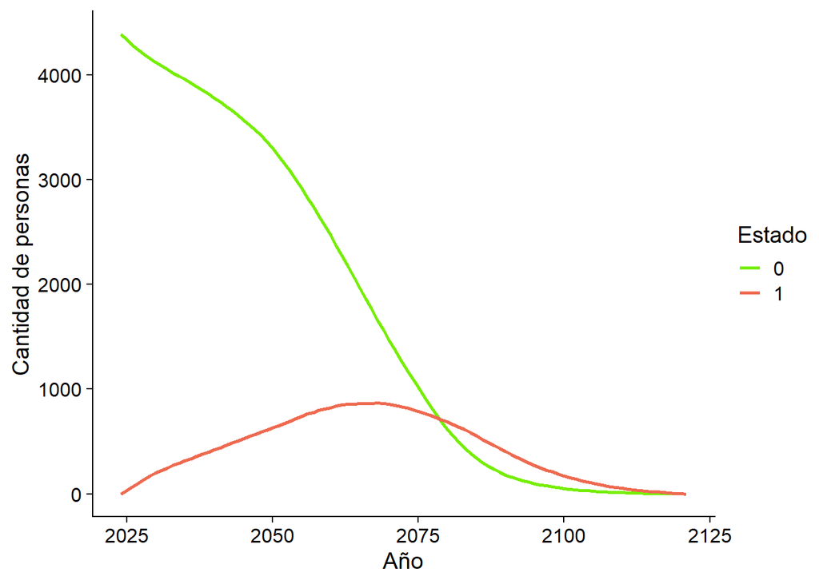

```r
# Se transpone el dataframe de personas mujeres
df_personas <- as.data.frame(t(esp_per_msen))

# Se agregan los años al dataframe
df_personas$anno <- 2024:2121

# Se cambian los nombres de las columnas
colnames(df_personas) <-
  c("est_0", "est_1", "est_2", "est_3", "est_4", "est_5", "annos")

# Gráfico de personas, estados 0 y 1
ggplot(df_personas, aes(x = annos)) +
  geom_line(aes(y = est_0, color = "0"), linewidth = 1) +
  geom_line(aes(y = est_1, color = "1"), linewidth = 1) +
  labs(x = "Año", y = "Cantidad de personas") +
  scale_colour_manual(name = "Estado",
                      values = c("0" = "chartreuse2",
                                 "1" = "coral2")) +
  cowplot::theme_cowplot()
```

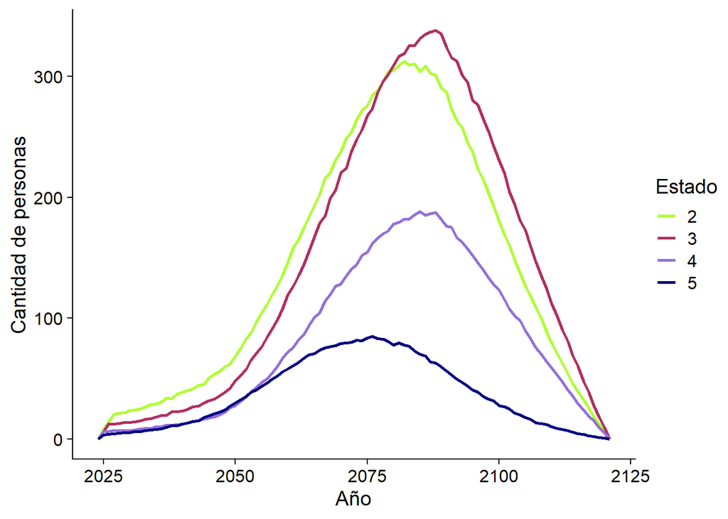

```r
# Gráfico de personas, estados del 2 al 5
ggplot(df_personas, aes(x = annos)) +
  geom_line(aes(y = est_2, color = "2"), linewidth = 1) +
  geom_line(aes(y = est_3, color = "3"), linewidth = 1) +
  geom_line(aes(y = est_4, color = "4"), linewidth = 1) +
  geom_line(aes(y = est_5, color = "5"), linewidth = 1) +
  labs(x = "Año", y = "Cantidad de personas") +
  scale_colour_manual(
    name = "Estado",
    values = c(
      "2" = "greenyellow",
      "3" = "maroon",
      "4" = "mediumpurple",
      "5" = "navy"
    )
  ) +
  cowplot::theme_cowplot()
```

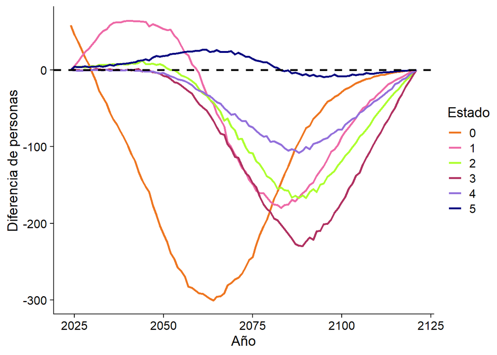

```r
# Dataframe de comparación de personas por sexo
df_comparacion <- esp_per_hsen - esp_per_msen

# Se transpone el dataframe de personas mujeres
df_comparacion <- as.data.frame(t(df_comparacion))

# Se agregan los años al dataframe
df_comparacion$anno <- 2024:2121

# Se cambian los nombres de las columnas
colnames(df_comparacion) <-
  c("est_0", "est_1", "est_2", "est_3", "est_4", "est_5", "annos")

# Gráfico de personas, estados del 0 al 1
ggplot(df_comparacion, aes(x = annos)) +
  geom_line(aes(y = est_0, color = "0"), linewidth = 1) +
  geom_line(aes(y = est_1, color = "1"), linewidth = 1) +
  geom_line(aes(y = est_2, color = "2"), linewidth = 1) +
  geom_line(aes(y = est_3, color = "3"), linewidth = 1) +
  geom_line(aes(y = est_4, color = "4"), linewidth = 1) +
  geom_line(aes(y = est_5, color = "5"), linewidth = 1) +
  geom_hline(
    yintercept = 0,
    linetype = "dashed",
    color = "black",
    linewidth = 1
  ) +
  labs(x = "Año", y = "Diferencia de personas") +
  scale_colour_manual(
    name = "Estado",
    values = c(
      "0" = "chocolate2",
      "1" = "hotpink2",
      "2" = "greenyellow",
      "3" = "maroon",
      "4" = "mediumpurple",
      "5" = "navy"
    )
  ) +
  cowplot::theme_cowplot()
```

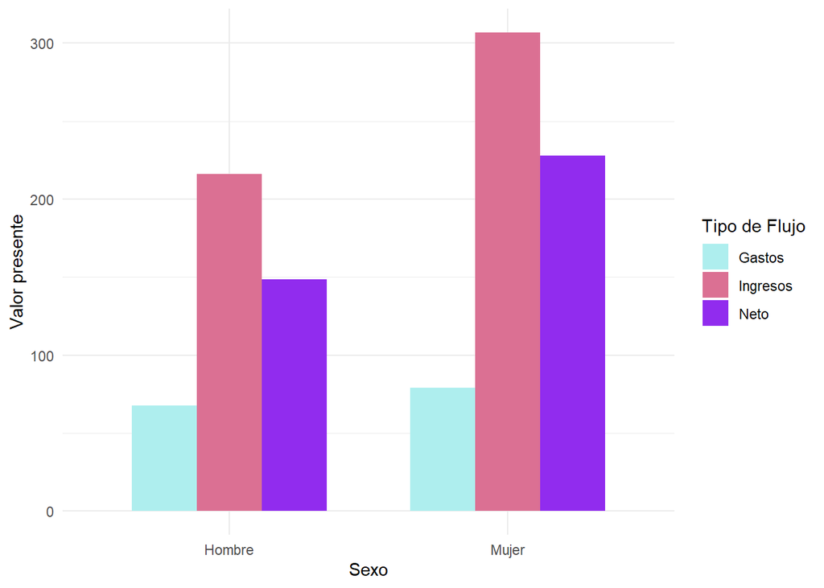

```r
# Dataframe para los gastos e ingresos
df_flujos <-
  data.frame(
    sexo = c("Hombre", "Mujer"),
    gastos = c(sum(esp_gast_hsen), sum(esp_gast_msen)),
    ingresos = c(sum(esp_ing_hsen), sum(esp_ing_msen))
  )

# Dataframe para el flujo neto
df_flujos <- df_flujos %>%
  mutate(neto = ingresos - gastos)

# Se ponen los flujos en formato largo
df_flujos <- df_flujos %>%
  pivot_longer(
    cols = c(gastos, ingresos, neto),
    names_to = "Categoria",
    values_to = "valor"
  )

# Gráfico de gastos, ingresos y flujo neto
ggplot(df_flujos, aes(
  x = sexo,
  y = (valor / 1000000000),
  fill = Categoria
)) +
  geom_bar(stat = "identity",
           position = "dodge",
           width = 0.7) +
  labs(x = "Sexo", y = "Valor presente") +
  scale_fill_manual(
    name = "Tipo de Flujo",
    values = c(
      "gastos" = "paleturquoise2",
      "ingresos" = "palevioletred",
      "neto" = "purple2"
    ),
    labels = c("gastos" = "Gastos", "ingresos" = "Ingresos", "neto" = "Neto")
  ) +
  theme_minimal()
```

## Probabilidades de transición

```r
# Copia de las probabilidades para no afectar a las originales
prob_hombres_mod <- prob_hombres
prob_mujeres_mod <- prob_mujeres

# Se hace un ciclo para la modificación
for (i in 1:6) {
  # Se guardan los elementos a sumar
  modificacion_hombres <- ((prob_hombres_mod[[i]][, 1] * 0.05) / 5)
  modificacion_mujeres <- ((prob_mujeres_mod[[i]][, 1] * 0.05) / 5)

  # Se modifica la primer columna
  prob_hombres_mod[[i]][, 1] <- prob_hombres_mod[[i]][, 1] * 0.95
  prob_mujeres_mod[[i]][, 1] <- prob_mujeres_mod[[i]][, 1] * 0.95

  # Se modifican las demás columnas
  prob_hombres_mod[[i]][, 2:6] <- prob_hombres_mod[[i]][, 2:6] + modificacion_hombres
  prob_mujeres_mod[[i]][, 2:6] <- prob_mujeres_mod[[i]][, 2:6] + modificacion_mujeres
}
```

Ahora determinamos las primas comerciales usando estas probabilidades

```r
# Vectores con las primas modifcadas
primas_modh <- c()
primas_modm <- c()

# Iteramos sobre cada edad para determinar las primas
for (x in 18:64) {
  # Vector con los factores de descuento
  v_j <- (1 + j) ^ (-(1:(115 - x)))

  # Generamos la matriz con los kpx para ambos sexos
  kpx_h <- kpx(x, prob_hombres_mod)
  kpx_m <- kpx(x, prob_mujeres_mod)

  # Se determina la prima para un hombre de edad x

  # Seguro de vida completo
  Ax_05 <- Ax05(x, v_j, kpx_h, prob_hombres_mod)

  # Anualidad de las primas
  ax00 <- 1 + ifelse(x < 64, (sum(v_j[1:(64 - x)] * kpx_h[1:(64 - x), 1])), 0)

  # Anualidad para el estado leve
  ax01 <- sum(v_j * kpx_h[, 2])

  # Anualidad para el estado moderado
  ax02 <- sum(v_j * kpx_h[, 3])

  # Anualidad para el estado severo
  ax03 <- sum(v_j * kpx_h[, 4])

  # Anualidad para el estado profundo
  ax04 <- sum(v_j * kpx_h[, 5])

  # Calculamos la prima con todo lo anterior
  prima <- (S * Ax_05 + c1 * ax01 + c2 * ax02 + c3 * ax03 + c4 * ax04) / (0.9 *
                                                                           ax00 - 0.1)
  # Guardamos la prima para alguien de edad x en el vector de primas
  primas_modh <- c(primas_modh, prima)

  # Analogamente se determina la prima para una mujer de edad x

  # Seguro de vida completo
  Ax_05 <- Ax05(x, v_j, kpx_m, prob_mujeres_mod)

  # Anualidad de las primas
  ax00 <- 1 + ifelse(x < 64, (sum(v_j[1:(64 - x)] * kpx_m[1:(64 - x), 1])), 0)

  # Anualidad para el estado leve
  ax01 <- sum(v_j * kpx_m[, 2])

  # Anualidad para el estado moderado
  ax02 <- sum(v_j * kpx_m[, 3])

  # Anualidad para el estado severo
  ax03 <- sum(v_j * kpx_m[, 4])

  # Anualidad para el estado profundo
  ax04 <- sum(v_j * kpx_m[, 5])

  # Calculamos la prima con todo lo anterior
  prima <- (S * Ax_05 + c1 * ax01 + c2 * ax02 + c3 * ax03 + c4 * ax04) / (0.9 *
                                                                           ax00 - 0.1)
  # Guardamos la prima para alguien de edad x en el vector de primas
  primas_modm <- c(primas_modm, prima)
}
```

Se procede a obtener el modelo estocástico con las primas modificadas.

```r
# Definimos la semilla para reproducibilidad
set.seed(2024)

# Cantidad de simulaciones
n_sim <- 10000

# Ingresos por estado de hombres y mujeres
ingresos_h_mod <- data.frame(
  "0" = c(primas_modh, rep(0, 51)),
  "1" = rep(0, 98),
  "2" = rep(0, 98),
  "3" = rep(0, 98),
  "4" = rep(0, 98),
  row.names = 18:115
)

ingresos_m_mod <- data.frame(
  "0" = c(primas_modm, rep(0, 51)),
  "1" = rep(0, 98),
  "2" = rep(0, 98),
  "3" = rep(0, 98),
  "4" = rep(0, 98),
  row.names = 18:115
)

# Determinamos las matrices asociadas a las simulaciones determinadas, tanto para hombres y mujeres
simulaciones_h <- modelo_estoc(n_sim, prob_hombres_mod, hombres_cartera, ingresos_h_mod)
simulaciones_m <- modelo_estoc(n_sim, prob_mujeres_mod, mujeres_cartera, ingresos_m_mod)

# Matrices con las esperanzas por estado y para cada año, para cada sexo
esperanzas_personas_hprob <- Reduce("+", simulaciones_h[[1]]) / n_sim
esperanzas_personas_mprob <- Reduce("+", simulaciones_m[[1]]) / n_sim

# Esperanzas por estado de gastos
esperanzas_gastos_hprob <- Reduce("+", simulaciones_h[[2]]) / n_sim
esperanzas_gastos_mprob <- Reduce("+", simulaciones_m[[2]]) / n_sim

# Esperanzas por estado de ingresos
esperanzas_ingresos_hprob <- Reduce("+", simulaciones_h[[3]]) / n_sim
esperanzas_ingresos_mprob <- Reduce("+", simulaciones_m[[3]]) / n_sim
```

Graficamos los resultados de este análisis de sensibilidad.

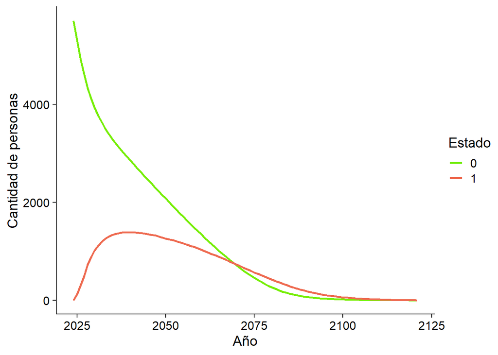

```r
# Se transpone el dataframe de personas hombres
df_personas <- as.data.frame(t(esperanzas_personas_hprob))

# Se agregan los años al dataframe
df_personas$anno <- 2024:2121

# Se cambian los nombres de las columnas
colnames(df_personas) <-
  c("est_0", "est_1", "est_2", "est_3", "est_4", "est_5", "annos")

# Gráfico de personas, estados 0 y 1
ggplot(df_personas, aes(x = annos)) +
  geom_line(aes(y = est_0, color = "0"), linewidth = 1) +
  geom_line(aes(y = est_1, color = "1"), linewidth = 1) +
  labs(x = "Año", y = "Cantidad de personas") +
  scale_colour_manual(name = "Estado",
                      values = c("0" = "chartreuse2",
                                 "1" = "coral2")) +
  cowplot::theme_cowplot()
```

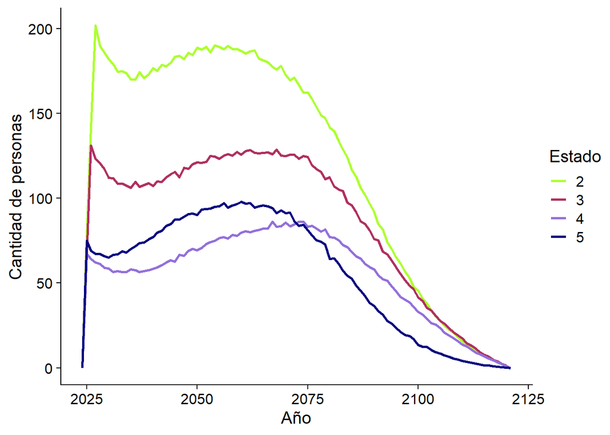

```r
# Gráfico de personas, estados del 2 al 5
ggplot(df_personas, aes(x = annos)) +
  geom_line(aes(y = est_2, color = "2"), linewidth = 1) +
  geom_line(aes(y = est_3, color = "3"), linewidth = 1) +
  geom_line(aes(y = est_4, color = "4"), linewidth = 1) +
  geom_line(aes(y = est_5, color = "5"), linewidth = 1) +
  labs(x = "Año", y = "Cantidad de personas") +
  scale_colour_manual(
    name = "Estado",
    values = c(
      "2" = "greenyellow",
      "3" = "maroon",
      "4" = "mediumpurple",
      "5" = "navy"
    )
  ) +
  cowplot::theme_cowplot()
```

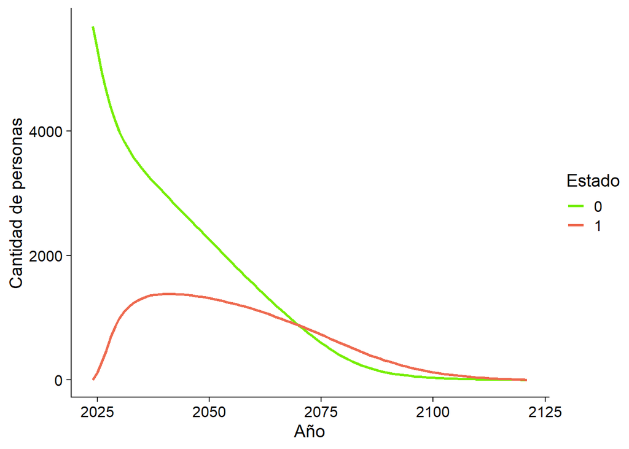

```r
# Se transpone el dataframe de personas mujeres
df_personas <- as.data.frame(t(esperanzas_personas_mprob))

# Se agregan los años al dataframe
df_personas$anno <- 2024:2121

# Se cambian los nombres de las columnas
colnames(df_personas) <-
  c("est_0", "est_1", "est_2", "est_3", "est_4", "est_5", "annos")

# Gráfico de personas, estados 0 y 1
ggplot(df_personas, aes(x = annos)) +
  geom_line(aes(y = est_0, color = "0"), linewidth = 1) +
  geom_line(aes(y = est_1, color = "1"), linewidth = 1) +
  labs(x = "Año", y = "Cantidad de personas") +
  scale_colour_manual(name = "Estado",
                      values = c("0" = "chartreuse2",
                                 "1" = "coral2")) +
  cowplot::theme_cowplot()
```

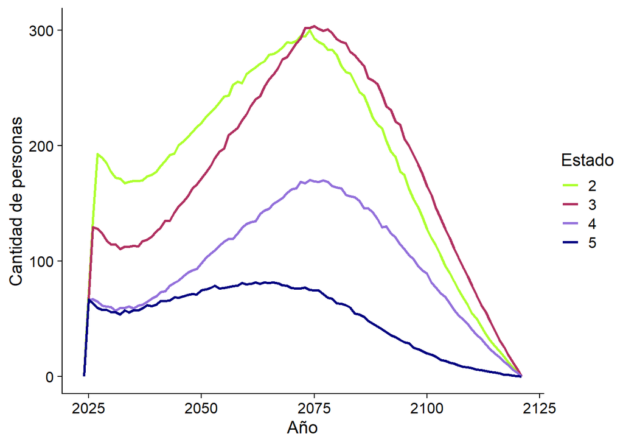

```r
# Gráfico de personas, estados del 2 al 5
ggplot(df_personas, aes(x = annos)) +
  geom_line(aes(y = est_2, color = "2"), linewidth = 1) +
  geom_line(aes(y = est_3, color = "3"), linewidth = 1) +
  geom_line(aes(y = est_4, color = "4"), linewidth = 1) +
  geom_line(aes(y = est_5, color = "5"), linewidth = 1) +
  labs(x = "Año", y = "Cantidad de personas") +
  scale_colour_manual(
    name = "Estado",
    values = c(
      "2" = "greenyellow",
      "3" = "maroon",
      "4" = "mediumpurple",
      "5" = "navy"
    )
  ) +
  cowplot::theme_cowplot()
```

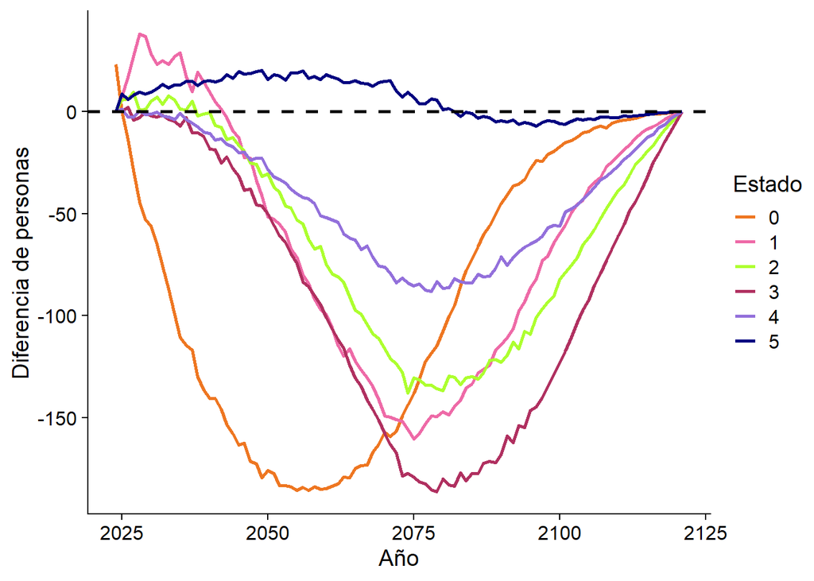

```r
# Dataframe de comparación de personas por sexo
df_comparacion <- esperanzas_personas_hprob - esperanzas_personas_mprob

# Se transpone el dataframe de personas mujeres
df_comparacion <- as.data.frame(t(df_comparacion))

# Se agregan los años al dataframe
df_comparacion$anno <- 2024:2121

# Se cambian los nombres de las columnas
colnames(df_comparacion) <-
  c("est_0", "est_1", "est_2", "est_3", "est_4", "est_5", "annos")

# Gráfico de personas, estados del 0 al 1
ggplot(df_comparacion, aes(x = annos)) +
  geom_line(aes(y = est_0, color = "0"), linewidth = 1) +
  geom_line(aes(y = est_1, color = "1"), linewidth = 1) +
  geom_line(aes(y = est_2, color = "2"), linewidth = 1) +
  geom_line(aes(y = est_3, color = "3"), linewidth = 1) +
  geom_line(aes(y = est_4, color = "4"), linewidth = 1) +
  geom_line(aes(y = est_5, color = "5"), linewidth = 1) +
  geom_hline(
    yintercept = 0,
    linetype = "dashed",
    color = "black",
    linewidth = 1
  ) +
  labs(x = "Año", y = "Diferencia de personas") +
  scale_colour_manual(
    name = "Estado",
    values = c(
      "0" = "chocolate2",
      "1" = "hotpink2",
      "2" = "greenyellow",
      "3" = "maroon",
      "4" = "mediumpurple",
      "5" = "navy"
    )
  ) +
  cowplot::theme_cowplot()
```

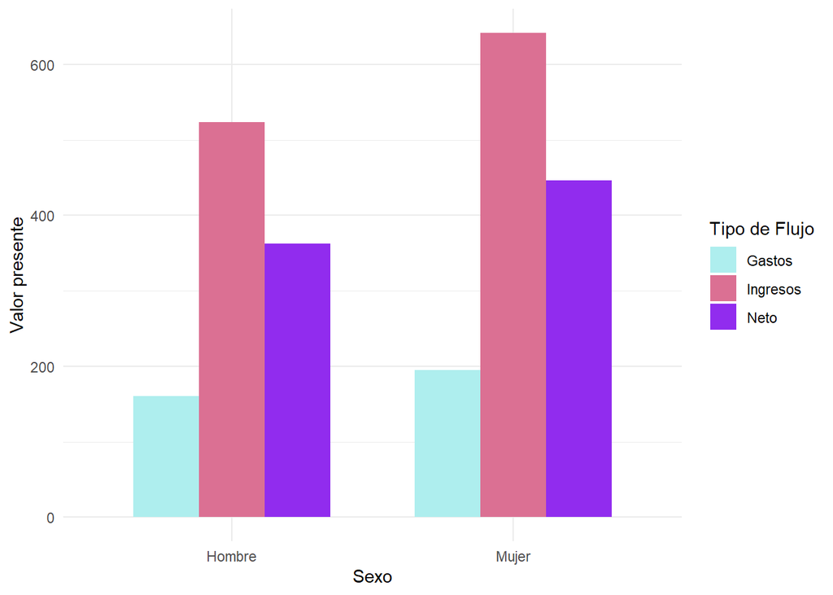

```r
# Dataframe para los gastos e ingresos
df_flujos <-
  data.frame(
    sexo = c("Hombre", "Mujer"),
    gastos = c(sum(esperanzas_gastos_hprob), sum(esperanzas_gastos_mprob)),
    ingresos = c(sum(esperanzas_ingresos_hprob), sum(esperanzas_ingresos_mprob))
  )

# Dataframe para el flujo neto
df_flujos <- df_flujos %>%
  mutate(neto = ingresos - gastos)

# Se ponen los flujos en formato largo
df_flujos <- df_flujos %>%
  pivot_longer(
    cols = c(gastos, ingresos, neto),
    names_to = "Categoria",
    values_to = "valor"
  )

# Gráfico de gastos, ingresos y flujo neto
ggplot(df_flujos, aes(
  x = sexo,
  y = (valor / 1000000000),
  fill = Categoria
)) +
  geom_bar(stat = "identity",
           position = "dodge",
           width = 0.7) +
  labs(x = "Sexo", y = "Valor presente") +
  scale_fill_manual(
    name = "Tipo de Flujo",
    values = c(
      "gastos" = "paleturquoise2",
      "ingresos" = "palevioletred",
      "neto" = "purple2"
    ),
    labels = c("gastos" = "Gastos", "ingresos" = "Ingresos", "neto" = "Neto")
  ) +
  theme_minimal()
```

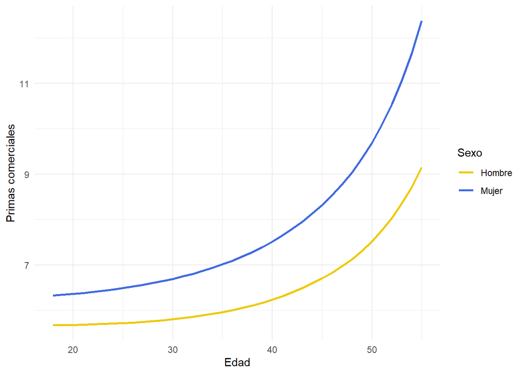

```r
# Sse juntan las primas para graficarlas
primas_brutas_mod <- data.frame(primas_modh, primas_modm)

# Nombre de filas y columnas
colnames(primas_brutas_mod) <- c("Hombre", "Mujer")
rownames(primas_brutas_mod) <- 18:64

# Gráficos de primas modificadas con gastos
ggplot(primas_brutas_mod[1:38, ], aes(x = 18:55)) +
  geom_line(aes(y = Hombre / 1000000, color = "H"), linewidth = 1) +
  geom_line(aes(y = Mujer / 1000000, color = "M"), linewidth = 1) +
  labs(x = "Edad", y = "Primas comerciales", color = "Leyenda") +
  scale_color_manual(
    name = "Sexo",
    values = c("H" = "gold2", "M" = "royalblue"),
    labels = c("H" = "Hombre", "M" = "Mujer")
  ) +
  theme_minimal()
```

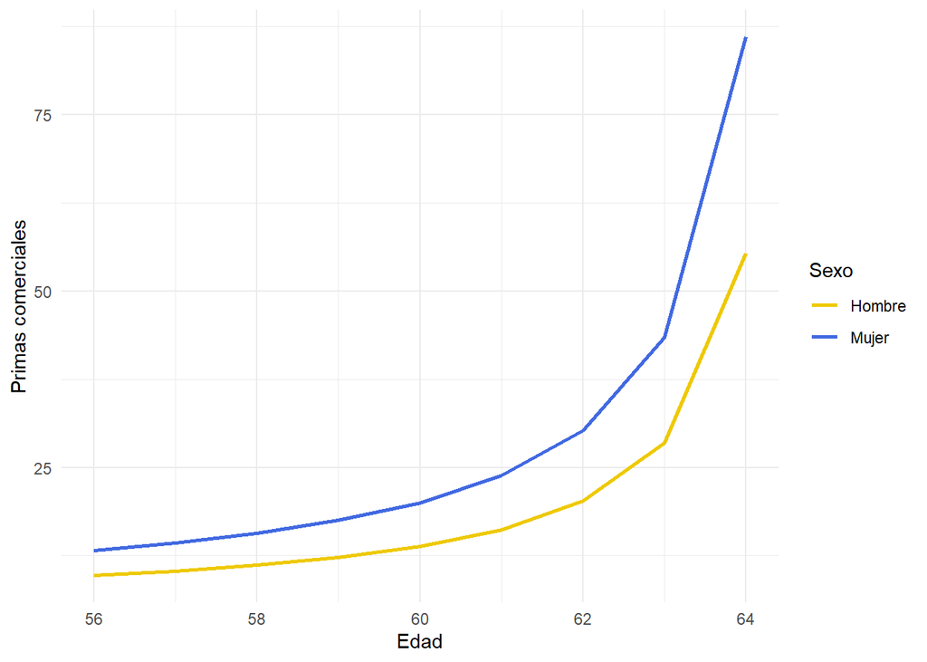

```r
ggplot(primas_brutas_mod[39:47, ], aes(x = 56:64)) +
  geom_line(aes(y = Hombre / 1000000, color = "H"), linewidth = 1) +
  geom_line(aes(y = Mujer / 1000000, color = "M"), linewidth = 1) +
  labs(x = "Edad", y = "Primas comerciales", color = "Leyenda") +
  scale_color_manual(
    name = "Sexo",
    values = c("H" = "gold2", "M" = "royalblue"),
    labels = c("H" = "Hombre", "M" = "Mujer")
  ) +
  theme_minimal()
```